# Rによる日本語テキスト処理

## RStudioを起動

*dplyr*というデータ操作のための拡張機能、ggplot2というグラフ作成ツールを利用するので、インストールしていない場合は以下を実行してください

```r
install.packages(c("dplyr", "ggplot2"), dependencies = TRUE)
```

## グラフで日本語を表示する準備

ホームフォルダに .Rprofile というファイルを作成します（これによって他のソフトなどに影響が出ることはありません）。以下1行を実行すると、石田の用意した設定ファイルがホームフォルダに作成されます。自身ですでに用意されている場合は以下の操作は不要です。

左下のConsole画面に以下をコピーペーストしてEnterを押し、一度、RStudioを終了させ、改めて起動してください

```r
source("http://rmecab.jp/R/Rprofile.R")#Rのインストール直後に1回だけ実行すれば以降は不要
```

## 命令を書くファイルを用意

File -> New File -> R Markdown

スクリプトにコードを書く

Rでの分析やグラフ作成に慣れるコツ

1. 自分でイチから書こうとしない
2. 基本はコピペ
3. コピペでうまくいったら少し 書き換えて試す
4. 自分一人で解決しようとしない
5. 人に聴く(slackのr-wakalangがおすすめ)

[r-wakalang へようこそ](https://qiita.com/uri/items/5583e91bb5301ed5a4ba)

## 日本語形態素解析

予め MeCabとRMeCabのインストールが必要です。詳細は https://sites.google.com/site/rmecab/home/install を参照ください。

```r
library(RMeCab) # RMeCabを利用する宣言
RMeCabC("本を読みました。") # 形態素解析
```

```
## [[1]]
## 名詞
## "本"
##
## [[2]]
## 助詞
## "を"
##
## [[3]]
##   動詞
## "読み"
##
## [[4]]
## 助動詞
## "まし"
##
## [[5]]
## 助動詞
##   "た"
##
## [[6]]
## 記号
## "。"
```

形態素解析の結果に名前を付けて保存

`x <-` 処理

とすると、処理した結果が `x` という名前で保存される

```r
## 活用語を原型で取得
x <- RMeCabC("本を読みました。", 1) # 形態素解の結果を x という名前で保存
unlist(x) # 結果を確認（ちなみに実行結果を保存した ｘ を変数、あるいはオブジェクトという
```

```
##   名詞   助詞   動詞 助動詞 助動詞   記号
##   "本"   "を" "読む" "ます"   "た"   "。"
```

## やってみる1

一時ファイルを作成して解析

1. `temp` と言う名前で一時ファイルを用意し
2. このファイルに文字列を書き込む(`write`)
3. このファイルを`RMeCabText`という命令で読み取る
4. 一時ファイルは不要なので削除(`unlink`)（何もしなくとも、いずれ自動的に削除される）

```r
temp <- tempfile()#テンポラリファイルの用意
write("春の日やあの世この世と馬車を駆り。" , temp)#そこに書き込み
RMeCabText(temp)#解析
```

```
## file = /tmp/RtmpZNc1zt/file26327480cece
```

```
## [[1]]
##  [1] "春"   "名詞" "一般" "*"    "*"    "*"    "*"    "春"   "ハル" "ハル"
##
## [[2]]
##  [1] "の"     "助詞"   "連体化" "*"      "*"      "*"      "*"
##  [8] "の"     "ノ"     "ノ"
##
## [[3]]
##  [1] "日"       "名詞"     "非自立"   "副詞可能" "*"        "*"
##  [7] "*"        "日"       "ヒ"       "ヒ"
##
## [[4]]
##  [1] "や"       "助詞"     "並立助詞" "*"        "*"        "*"
##  [7] "*"        "や"       "ヤ"       "ヤ"
##
## [[5]]
##  [1] "あの世" "名詞"   "一般"   "*"      "*"      "*"      "*"
##  [8] "あの世" "アノヨ" "アノヨ"
##
## [[6]]
##  [1] "この世" "名詞"   "一般"   "*"      "*"      "*"      "*"
##  [8] "この世" "コノヨ" "コノヨ"
##
## [[7]]
##  [1] "と"       "助詞"     "並立助詞" "*"        "*"        "*"
##  [7] "*"        "と"       "ト"       "ト"
##
## [[8]]
##  [1] "馬車"   "名詞"   "一般"   "*"      "*"      "*"      "*"
##  [8] "馬車"   "バシャ" "バシャ"
##
## [[9]]
##  [1] "を"     "助詞"   "格助詞" "一般"   "*"      "*"      "*"
##  [8] "を"     "ヲ"     "ヲ"
##
## [[10]]
##  [1] "駆り"       "動詞"       "自立"       "*"          "*"
##  [6] "五段・ラ行" "連用形"     "駆る"       "カリ"       "カリ"
##
## [[11]]
##  [1] "。"   "記号" "句点" "*"    "*"    "*"    "*"    "。"   "。"   "。"
```

```r
unlink(temp)#一時ファイルを明示的に削除
```

## やってみる2

*udpipe*パッケージを試してみる。RStudioを起動して左下Console画面で以下のように入力します。

```r
# インストールが必要な場合は以下を実行
install.packages("udpipe")
```

インストールができれば以下のように実行

```r
library(udpipe) #パッケージの利用宣言
txt <- "本を読みました。" # 文字列
x <- udpipe(txt, object = "japanese") # 対象言語を指定（初回は辞書がダウンロードされる）
x # 結果を確認
```

```
##   doc_id paragraph_id sentence_id         sentence start end term_id
## 1   doc1            1           1 本を読みました。     1   1       1
## 2   doc1            1           1 本を読みました。     2   2       2
## 3   doc1            1           1 本を読みました。     3   4       3
## 4   doc1            1           1 本を読みました。     5   6       4
## 5   doc1            1           1 本を読みました。     7   7       5
## 6   doc1            1           1 本を読みました。     8   8       6
##   token_id token lemma  upos xpos feats head_token_id dep_rel deps
## 1        1    本    本  NOUN   NN  <NA>             3     obj <NA>
## 2        2    を    を   ADP   PS  <NA>             1    case <NA>
## 3        3  読み  読む  VERB   VV  <NA>             0    root <NA>
## 4        4  まし  ます   AUX   AV  <NA>             3     aux <NA>
## 5        5    た    た   AUX   AV  <NA>             3     aux <NA>
## 6        6    。    。 PUNCT  SYM  <NA>             3   punct <NA>
##              misc
## 1   SpaceAfter=No
## 2   SpaceAfter=No
## 3   SpaceAfter=No
## 4   SpaceAfter=No
## 5   SpaceAfter=No
## 6 SpacesAfter=\\n
```

## 青空文庫の利用

zipファイルのURLを右クリック（MacではCtrlを押しながらクリック）でコピーしておく

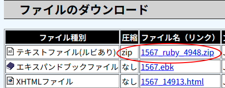

走れメロス

https://www.aozora.gr.jp/cards/000035/files/1567_ruby_4948.zip

## 青空文庫の利用

Rで小説をダウンロード

1. 外部にある青空文庫読み込み機能を取り込む(`source`)
2. `Aozora` 命令にzipファイルのURLを指定
3. 取り込まれたファイル名が`x`に保存されているので確認

```r
source("http://rmecab.jp/R/Aozora.R") # 青空文庫からテキストをダウンロードするための機能
# 丸括弧引用符内にURLをコピー。前後に余計な空白（スペース）を入れないように
x <- Aozora("https://www.aozora.gr.jp/cards/000035/files/1567_ruby_4948.zip")#引用符内のURLを適宜変更
```

```
## example: folder_name <- Aozora('http://www.aozora.gr.jp/cards/000081/files/462_ruby_716.zip')
```

```r
x #ダウンロードされたファイルの場所（なおオリジナルはgetwd()で表示されるフォルダに保存されている）
```

```
## [1] "./NORUBY/hashire_merosu2.txt"
```

## ファイルの確認

ダウンロードしたファイルには入力者によるメタ情報、ルビが入力されているが、上記の方法でダウンロードした場合は、自動的に削除されている

以下は、ダウンロードされたファイルを確認するために、冒頭の10行ほどを読み込んでみている。変換前のファイル（解凍直後）と、`Aozora()`で変換した後のファイルを比べてみる。

```r
readLines(x, 8)#変換後のファイルの冒頭8行
```

```
## [1] "走れメロス"
## [2] "太宰治"
## [3] ""
## [4] ""
## [5] "　メロスは激怒した。必ず、かの邪智暴虐の王を除かなければならぬと決意した。メロスには政治がわからぬ。メロスは、村の牧人である。笛を吹き、羊と遊んで暮して来た。けれども邪悪に対しては、人一倍に敏感であった。きょう未明メロスは村を出発し、野を越え山越え、十里はなれた此のシラクスの市にやって来た。メロスには父も、母も無い。女房も無い。十六の、内気な妹と二人暮しだ。この妹は、村の或る律気な一牧人を、近々、花婿として迎える事になっていた。結婚式も間近かなのである。メロスは、それゆえ、花嫁の衣裳やら祝宴の御馳走やらを買いに、はるばる市にやって来たのだ。先ず、その品々を買い集め、それから都の…
## [6] "「王様は、人を殺します。」"
## [7] "「なぜ殺すのだ。」"
## [8] "「悪心を抱いている、というのですが、誰もそんな、悪心を持っては居りませぬ。」"
```

```r
readLines("hashire_merosu.txt", 8) #変換前ファイルの冒頭8行（ただし以下の表示は文字化けしています）
```

```
## [1] "\x91\x96\x82ꃁ\x83\x8d\x83X"
## [2] "\x91\xbe\x8dɎ\xa1"
## [3] ""
## [4] "-------------------------------------------------------"
## [5] "\x81y\x83e\x83L\x83X\x83g\x92\x86\x82Ɍ\xbb\x82\xea\x82\xe9\x8bL\x8d\x86\x82ɂ\u0082\xa2\x82āz"
## [6] ""
## [7] "\x81s\x81t\x81F\x83\x8b\x83r"
## [8] "\x81i\x97\xe1\x81j\x8eגq\x96\\\x8bs\x81s\x82\xb6\x82Ⴟ\x82ڂ\xa4\x82\xac\x82Ⴍ\x81t"
```

```r
# MacやLinuxでは文字コードの関係で以下のように実行しないと文字化けする
readLines("hashire_merosu.txt", 11) %>% iconv(from = "Shift-Jis")#Mac/Linuxではこのように実行
```

```
##  [1] "走れメロス"
##  [2] "太宰治"
##  [3] ""
##  [4] "-------------------------------------------------------"
##  [5] "【テキスト中に現れる記号について】"
##  [6] ""
##  [7] "《》：ルビ"
##  [8] "（例）邪智暴虐《じゃちぼうぎゃく》"
##  [9] ""
## [10] "｜：ルビの付く文字列の始まりを特定する記号"
## [11] "（例）疲労｜困憊《こんぱい》"
```

## 文字コード

Mac Linux は言語を問わず UTF-8

日本語Windowsは CP932(Shift-Jis)

分析対象とするファイルが、適切な文字コードで保存されているか注意

## 形態素解析

1. `docDF()`命令にファイル名(`x`)と分析方法(`type`) を指定
2. この結果を`merosu`という名前で保存

```r
merosu <- docDF(x, type = 1)#type=1は単語ベースで解析、type=0は文字ベース
```

```
## file_name =  ./NORUBY/hashire_merosu2.txt opened
## number of extracted terms = 1314
## now making a data frame. wait a while!
```

## 結果を確認

テキストデータの解析結果は大きくなるので、冒頭(`head()`) あるいは末尾(`tail()`)だけを確認

```r
head(merosu, 15)
```

```
##          TERM   POS1         POS2 hashire_merosu2.txt
## 1        ――   記号         一般                   2
## 2          　   記号         空白                  34
## 3          、   記号         読点                 556
## 4          。   記号         句点                 459
## 5          々   記号         一般                   6
## 6          「   記号       括弧開                  62
## 7          」   記号       括弧閉                  62
## 8          あ 感動詞            *                   1
## 9        ああ 感動詞            *                  15
## 10 あからめる   動詞         自立                   2
## 11     あげる   動詞         自立                   2
## 12       あす   名詞     副詞可能                   3
## 13     あたり   名詞         一般                   1
## 14   あちこち   名詞       代名詞                   1
## 15   あっぱれ   名詞 形容動詞語幹                   1
```

## 語彙数と総語数

```r
NROW(merosu)#語彙数
```

```
## [1] 1314
```

```r
sum(merosu$hashire_merosu2.txt)#各語彙の出現頻度合計
```

```
## [1] 6432
```

## データ操作

パイプ演算子％＞％に慣れる

| データ | ％＞％ | 処理 |
| --- | --- | --- |

`select` で列を選択する。言葉で表現すると、

1. `merosu` データ から
2. ％＞％
3. `TERM1,POS1` 列を `select` 選んで
4. ％＞％
5. 最初(`head`) を表示

```r
merosu %>% select(TERM, POS1) %>% head()#TERM列とPOS1列を選択し、その冒頭を表示
```

```
##   TERM POS1
## 1 ―― 記号
## 2   　 記号
## 3   、 記号
## 4   。 記号
## 5   々 記号
## 6   「 記号
```

## データ操作

`arrange` で昇順に並べる（末尾(`tail`)に高頻度語が並ぶ）。

1. `merosu` データ から
2. ％＞％
3. `hashire_merosu2.txt` 列の数値順に `arrange` 並べ替えて
4. ％＞％
5. 最後の(`tail`) の20行を表示

```r
merosu %>% arrange(hashire_merosu2.txt)  %>% tail(20)#末尾の20行を表示
```

```
##        TERM   POS1     POS2 hashire_merosu2.txt
## 1295     で   助詞   格助詞                  44
## 1296     と   助詞   格助詞                  48
## 1297   いる   動詞   非自立                  50
## 1298     「   記号   括弧開                  62
## 1299     」   記号   括弧閉                  62
## 1300   する   動詞     自立                  74
## 1301     も   助詞   係助詞                  74
## 1302 メロス   名詞     一般                  74
## 1303     私   名詞   代名詞                  76
## 1304     が   助詞   格助詞                  77
## 1305     の   名詞   非自立                  78
## 1306     だ 助動詞        *                 173
## 1307     に   助詞   格助詞                 182
## 1308     の   助詞   連体化                 213
## 1309     を   助詞   格助詞                 220
## 1310     た 助動詞        *                 222
## 1311     て   助詞 接続助詞                 237
## 1312     は   助詞   係助詞                 267
## 1313     。   記号     句点                 459
## 1314     、   記号     読点                 556
```

## 頻度を確認

`filter` で条件抽出（等しいを`==`で表す）。 頻度(frequency)を表す列の名前が、読みこんだファイル名になっているのに注意。

1. `merosu` データ から
2. ％＞％
3. `hashire_merosu2.txt` 列の数値が1である行にしぼって `filter`
4. ％＞％
5. その行数(`NROW`)を表示

```r
merosu %>% filter(hashire_merosu2.txt == 1 ) %>%  NROW()#頻度1の単語の個数（行数）
```

```
## [1] 811
```

## 条件抽出

品詞分類で抽出

1. `merosu` データ から
2. ％＞％
3. 品詞分類(`POS1`)を名詞にしぼって(`filter`)
4. ％＞％
5. 冒頭(`head`)を表示

```r
merosu %>% filter(POS1 == "名詞")  %>% head()
```

```
##       TERM POS1         POS2 hashire_merosu2.txt
## 1     あす 名詞     副詞可能                   3
## 2   あたり 名詞         一般                   1
## 3 あちこち 名詞       代名詞                   1
## 4 あっぱれ 名詞 形容動詞語幹                   1
## 5     あて 名詞         一般                   1
## 6   あなた 名詞       代名詞                   3
```

## 棒グラフ

Rでのグラフ作成と作成方法は奥が深く、数時間では説明しきれないので、以下は試すだけで。

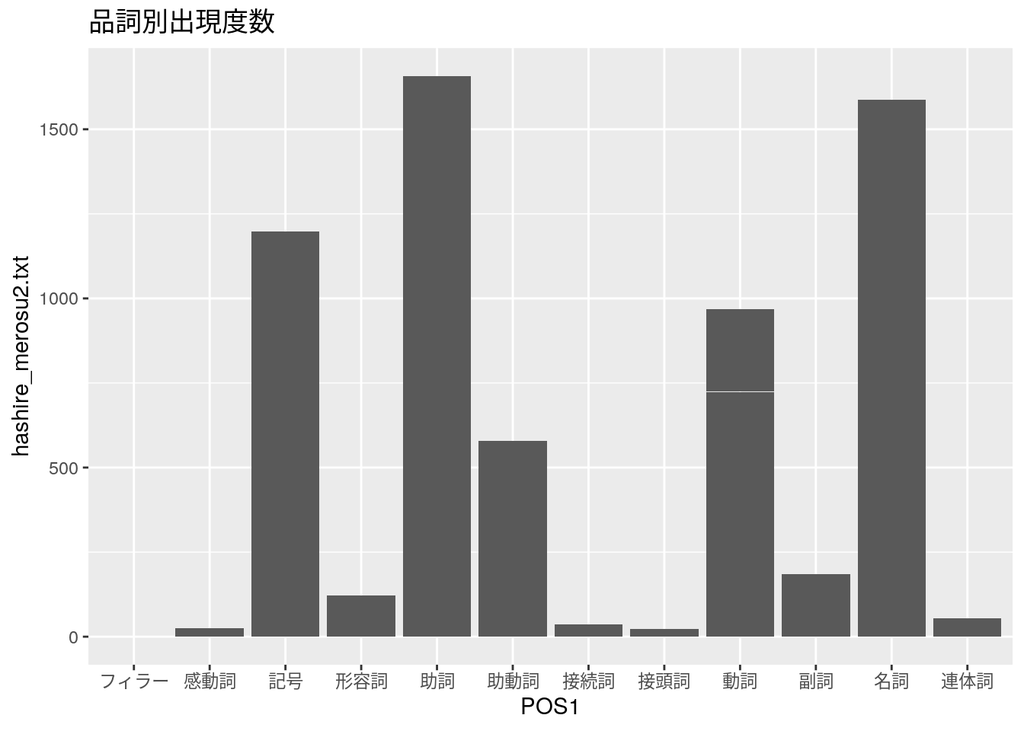

```r
library(ggplot2)
merosu  %>% ggplot() + geom_bar(aes(x =POS1, y = hashire_merosu2.txt), stat = "identity") + ggtitle("品詞別出現度数")
```

```r
# Macの場合は + theme_gray (base_family = "HiraKakuPro-W3")#を追加
```

## より複雑な条件

品詞大分類と細分類で絞り込む

1. `merosu` データ から
2. ％＞％
3. 品詞分類(`POS1`)が名詞で、細分類(`POS2`)がサ変接続にしぼって(`filter`)
4. ％＞％
5. 冒頭(`head`)の５行を表示

```r
merosu %>% filter(POS1 == "名詞", POS2 == "サ変接続") %>% head(5)
```

```
##         TERM POS1     POS2 hashire_merosu2.txt
## 1     お詫び 名詞 サ変接続                   1
## 2 ひとり合点 名詞 サ変接続                   1
## 3     一ぱい 名詞 サ変接続                   4
## 4       一撃 名詞 サ変接続                   1
## 5       一睡 名詞 サ変接続                   1
```

## Wordcloud

頻度に下限を指定して描画

1. `merosu` データ から
2. ％＞％
3. 品詞分類(`POS1`)が名詞で、細分類(`POS2`)がサ変接続の単語で、かつ頻度が2以上(`>= 2`)にしぼって(`filter`)
4. ％＞％
5. 単語列(`TERM`) と頻度列(`hashire_merosu2.txt`) をデータとして選んで(`select`)
6. `wordcloud` を描く

```r
library(wordcloud2)
merosu %>% filter(POS1 == "名詞", POS2 == "サ変接続", hashire_merosu2.txt >= 2) %>% select(TERM, hashire_merosu2.txt) %>% wordcloud2()
```

[interactive chart not shown]

## ネットワークグラフ

バイグラム

「本を読んだ」

[output not shown]

```r
# 例
(docDF(data.frame(X ="本を読んだ"), "X", type=1, N=2))#事例です：この命令の詳細を気にする必要ありません
```

```
## number of extracted terms = 3
## now making a data frame. wait a while!
```

```
##      TERM        POS1        POS2 Row1
## 1 を-読む   助詞-動詞 格助詞-自立    1
## 2   本-を   名詞-助詞 一般-格助詞    1
## 3 読む-だ 動詞-助動詞      自立-*    1
```

`docDF` 命令に `n=2, nDF=1` 、そして名詞と形容詞、動詞だけを抽出するという記述`pos = c("名詞", "形容詞", "動詞")`を追加

1. `docDF`で名詞、形容詞、動詞に絞ってバイグラムの頻度を表形式にまとめる
2. これを`bigram`という名前で保存する（`<-`) 3. `hashire_merosu2.txt`列の数値で並べ替える
3. ％＞％
4. 最後(`tail`)の20行だけ残す

```r
bigram <- docDF(x, type = 1, N=2, nDF = 1, pos = c("名詞", "形容詞", "動詞"))
```

```
## file_name =  ./NORUBY/hashire_merosu2.txt opened
## number of extracted terms = 2304
## now making a data frame. wait a while!
```

```r
bigram %>% arrange(hashire_merosu2.txt) %>% tail(20)
```

```
##        N1     N2      POS1          POS2 hashire_merosu2.txt
## 2285   君     私 名詞-名詞 代名詞-代名詞                   4
## 2286 待つ   いる 動詞-動詞   自立-非自立                   4
## 2287 掻く わける 動詞-動詞     自立-自立                   4
## 2288   為   走る 名詞-動詞   非自立-自立                   4
## 2289   私   殴る 名詞-動詞   代名詞-自立                   4
## 2290   頬   殴る 名詞-動詞     一般-自立                   4
## 2291 ある     の 動詞-名詞   自立-非自立                   5
## 2292 なる   いる 動詞-動詞   自立-非自立                   5
## 2293 やる     の 動詞-名詞 非自立-非自立                   5
## 2294   三     日 名詞-名詞       数-接尾                   5
## 2295   人   殺す 名詞-動詞     一般-自立                   5
## 2296 来る     の 動詞-名詞 非自立-非自立                   5
## 2297   私 信じる 名詞-動詞   代名詞-自立                   5
## 2298   陽   沈む 名詞-動詞     一般-自立                   5
## 2299 する   いる 動詞-動詞   自立-非自立                   6
## 2300 いる     の 動詞-名詞 非自立-非自立                   7
## 2301 殺す   れる 動詞-動詞     自立-接尾                   7
## 2302 帰る   来る 動詞-動詞   自立-非自立                   8
## 2303 走る     の 動詞-名詞   自立-非自立                   8
## 2304   の     私 名詞-名詞 非自立-代名詞                  10
```

## データをグラフ化

単語間のつながりを定義

```r
library(igraph)
bigram2  <- bigram %>% select(N1, N2, hashire_merosu2.txt)  %>% filter(hashire_merosu2.txt > 2 )# %>%
bigram2 <- graph_from_data_frame(bigram2)
```

## 描画

- 通常のプロット
- インタラクティブ

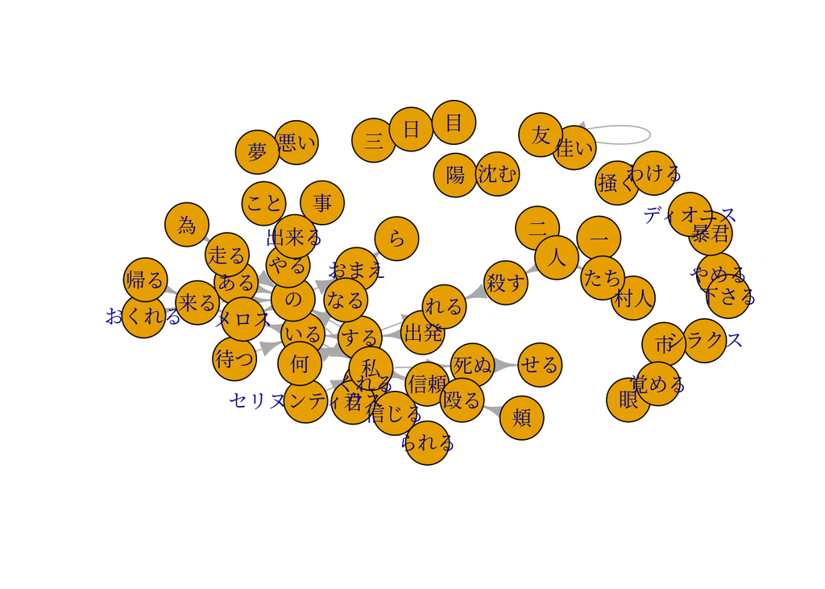

```r
#par(mar=c(0,0,0,0))
plot(bigram2, asp=0)
```

```r
# 以下を実行すると、別Windowにインタラクティブにマウス操作可能なグラフが生成される
# ただしMacの場合は https://www.xquartz.org/ のインストールが必要
# tkplot(bigram2, asp=0,vertex.color = "SkyBlue")
```